# Analysis of serial dependence in functional time series residuals

Hassan Maissoro

2025-02-26

## 1 Introduction

Our aim is to test the assumption that FTS measurement errors are independent.

### 1.1 Observation Scheme

We consider a stationary FTS $ {X_n} $ observed over a **discrete grid** or at **random points**:
$$Y_{n,i} = X_n(T_{n,i}) + \sigma(T_{n,i})\varepsilon_{n,i}, \quad n = 1,
..., N, \quad i = 1, ..., M_n.$$
where:

- $\{X_n\}$ is a strictly FTS.
- $T_{n,i}$ are i.i.d. samples of a random variable $T$ (or fixed points in **common design**).
- $M_n$ are i.i.d. samples of a random variable $ M$ with expectation $\lambda$.
- $\varepsilon_{n,i}$ are i.i.d. samples of $\varepsilon$ with mean 0 and unit variance.
- $\sigma$ is a Lipschitz continuous function accounting for heteroscedasticity.
- $\{X_n\}, M, T, \varepsilon$ are mutually independent.

### 1.2 Naradaya-Watson

Let $\widehat{X}_n(t;h)$ be the Naradaya-Watson estimator of $X_n$ at $t$ obtained using the sample $\{(T_{n,i}, Y_{n,i}),\ i = 1, ..., M_n\}$ and some bandwidth parameter $h$. The parameter $h$ can be selected by :

1. Cross-Validation over each curve;
2. The Adaptive optimal smoothing method proposed by *Golovkine et al. (2022)*. NB : Technical adaptation required for FTS.
3. The adaptive bandwidth optimal bandwidth parameter for mean or (auto)covariance estimation.

### 1.3 Smoothing residuals

Let the smoothing residuals be for each curve $X_n$:
$$\widehat{e}_{n,i} = Y_{n,i} - \widehat{X}_n(T_{n,i};h), \qquad i=1,
..., M_n.$$
Our aim is to test the serial dependence of the residuals for the whole FTS:

$$\{\widehat{e}_{n,i},\; n=1, ..., N,\; i=1, ..., M_n\}.$$

### 1.4 Analysis scenarios

1. **Scenario 1** : The Naive approach. We consider $\{\widehat{e}_{n,i},\; n=1, ..., N,\; i=1, ..., M_n\}$ as one sample of FTS.
   - Diagnostic plots : ACF, PACF, etc.
   - Tests in time series analysis : Ljung-Box test, etc.
   - Nonparametric Tests for Serial Dependence : Kendall’s tau, Wald–Wolfowitz runs test, Brock-Dechert-Scheinkman (BDS) Test, etc.
2. **Scenario 2** : We consider $\{\widehat{e}_{n,i},\; n=1, ..., N,\; i=1, ..., M_n\}$ as $N$ samples $\{\widehat{e}_{n,i},\; i=1, ..., M_n\}$, $n=1, ..., N$.
   - Permutation with respect to $n$ and application of the analysis of **Scenario 1**.
   - Analysis of the serial dependence of each sample $\{\widehat{e}_{n,i},\; i=1, ..., M_n\}$.
   - Analysis of the serial dependence of the whole sample $\{\widehat{e}_{n,i},\; i=1, ..., M_n\}$, $n=1, ..., N$, using
     - Multivariate independence tests Across curves : multivariate Ljung-Box test, etc.
     - Pairwise independence tests
     - Etc.
3. **Scenario 3:** We consider $\{\widehat{e}_{n,i},\; n=1, ..., N,\; i=1, ..., M_n\}$ as $N$ samples $\{\widehat{e}_{n,i},\; i=1, ..., M_n\}$, $n=1, ..., N$.
   - For each curve, find a summary statistics of the resiudals. Let $f$ be some summary statistic of the residuals such Variance, Mean, Other Statistics, etc. and define
     $$\widehat{S}_n = f(\{\widehat{e}_{n,i},\; i=1,
     ..., M_n\})$$
   - Study the variations of $\{\widehat{S}_n\}$

## 2 Application of the analysis scenarios

- We consider the **random** and **Common** resign with sample size $N=150$ and $\lambda = 90$.
- Homoscedasticity noise $\varepsilon \sim \mathcal{N}(0, 0.0625)$.
- We use cross-validation to select the bandwidth parameter $h$ of the Nadaraya-Watson estimator.

### 2.1 Scenario 1

It is the Naive approach. We consider $\{\widehat{e}_{n,i},\; n=1, ..., N,\; i=1, ..., M_n\}$ as one sample of FTS.

- Diagnostic plots : ACF, PACF, etc.
- Tests in time series analysis : Ljung-Box test, etc.
- Nonparametric Tests for Serial Dependence : Kendall’s tau, Wald–Wolfowitz runs test, Brock-Dechert-Scheinkman (BDS) Test, etc.

#### 2.1.1 Random design

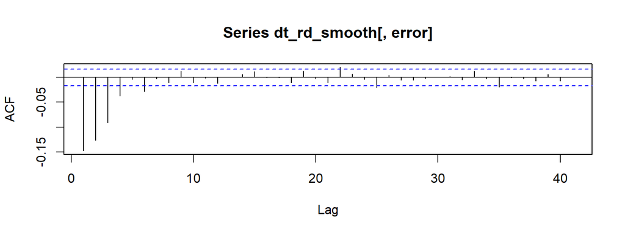

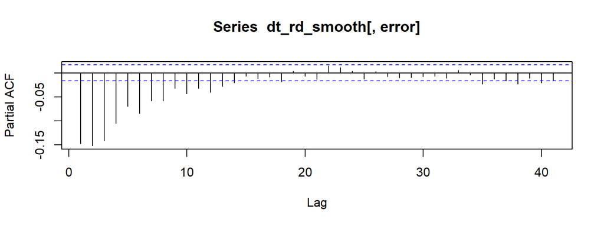

#### 2.1.2 Common design

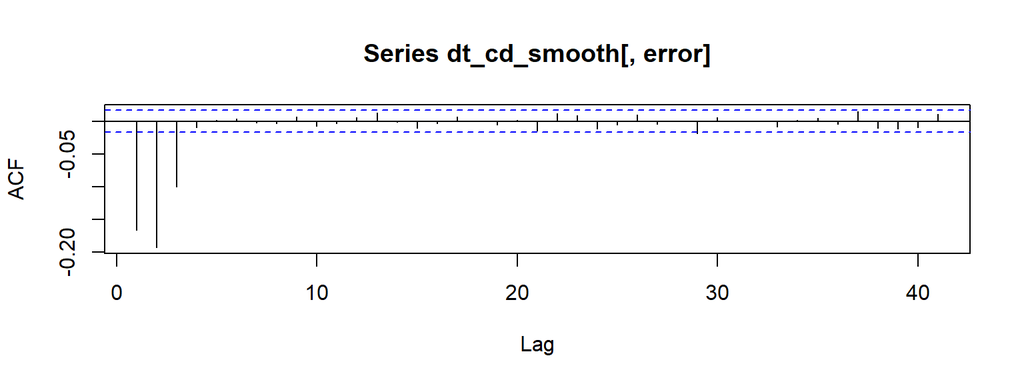

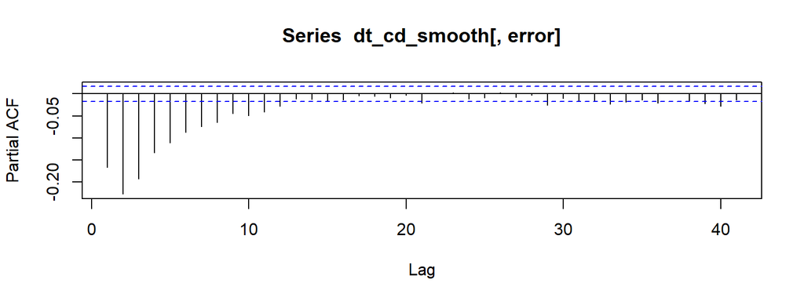